# MovieLens Rating Prediction Project

Nabeel Khan

16-May-2020

This report is part of the ‘HarvardX: PH125.9x Data Science: Capstone’ course. The goal of this work is to use the acquired data science skills to develop a recomender system.

Recommender systems predict users’ interests and recommend product items that quite likely are interesting for them. These systems use state of the art machine learning algorithms to make precise predictions. The recommender systems are most commonly used by Netflix, YouTube, Spotify, Amazon, or Ebay.

One of the famous success story of the recommender system is the Netflix competition. In 2006, Netflix announced to award 1 milloin dollar prize to a team, which can come up with the best filtering algorithm to predict user ratings for movies based on previous ratings. The winners were announced in 2009 and the winning team improved the accuracy of Netfliix system system by 10%.

The aim of this project is to dveleop a recomender system using machine learning to predict movie ratings based on suitable predictors.

Netflix dataset is not available online. So, we will use 10M version of MoiveLens dataset in this project . The dataset is generated by the GroupLens, which is a research lab in the Department of Computer Science and Engineering at the University of Minnesota. The dataset contains 10 million ratings. We will split the data into training and validaiton sets to develop the machine lelarning algorithm.

The performace of the model will be evaluated with the Root Mean Square Error (RMSE) . The RMSE is a standard method to measure the error of a model in predicting quantitative data and is defined in Equation .

$$\begin{equation}
\label{eq:rmse}
RMSE = \sqrt{\frac{1}{n}\displaystyle\sum_{i=1}^{n} (\hat{y}_{i}-y_{i})^{2}}
\end{equation}$$

$\hat{y}_{i}$ refers to the predicted values by the model, ${y}_{i}$ refers to the actual values, and refers to the total number of oservations. The RMSE is one of the very useful metrics to analyse the performance of models, but it can produce biased results in the presence of large number of outliers. In this project, the RMSE will indicate how close model predictions are to the actual ratings in the validation set.

```r
################################
#  Install packages (if not installed)
################################
# Note: this process could take a couple of minutes
if(!require(tidyverse)) install.packages("tidyverse", repos = "http://cran.us.r-project.org")
if(!require(caret)) install.packages("caret", repos = "http://cran.us.r-project.org")
if(!require(data.table)) install.packages("data.table", repos = "http://cran.us.r-project.org")
if(!require(lubridate)) install.packages("lubridate", repos = "http://cran.us.r-project.org")
if(!require(dplyr)) install.packages("dplyr", repos = "http://cran.us.r-project.org")


################################
# Load libraries
################################
library(lubridate)
library(tidyverse)
library(dplyr)
library(lubridate)
```

```r
################################
# Downloading data
################################
# MovieLens 10M dataset:
 # https://grouplens.org/datasets/movielens/10m/
 # http://files.grouplens.org/datasets/movielens/ml-10m.zip

url <- "http://files.grouplens.org/datasets/movielens/ml-10m.zip"

dl <- tempfile()
    download.file(url, dl)

ratings <- fread(text = gsub("::", "\t", readLines(unzip(dl, "ml-10M100K/ratings.dat"))), col.names = c("userId", "movieId", "rating", "timestamp"))
movies <- str_split_fixed(readLines(unzip(dl, "ml-10M100K/movies.dat")), "\\::", 3)
   colnames(movies) <- c("movieId", "title", "genres")
   movies <- as.data.frame(movies) %>% mutate(movieId =   as.numeric(levels(movieId))[movieId], title = as.character(title), genres =    as.character(genres))

################################
# Creating edx and validation sets
################################
movielens <- left_join(ratings, movies, by = "movieId")


# Validation set will be 10% of MovieLens data
set.seed(1, sample.kind = "Rounding")
test_index <- createDataPartition(y = movielens$rating, times = 1, p = 0.1, list = FALSE)

edx <- movielens[-test_index,]
temp <- movielens[test_index,]

# Make sure userId and movieId in validation set are also in edx set
validation <- temp %>%
      semi_join(edx, by = "movieId") %>%
      semi_join(edx, by = "userId")

# Add rows removed from validation set back into edx set
removed <- anti_join(temp, validation)
 edx <- rbind(edx, removed)

 # Removing the objects no longer required
rm(dl, ratings, movies, test_index, temp, movielens, removed)
```

In this section, we explore the dataset to get familiar with it. We also also perform some data wrangling. Data wrangling is the process of cleaning, structuring or enriching raw data into a desired format to make better decisions and get more meaningful insights.

We look at the first six rows of dataset. We can see that dataset contains six variables namely `userID'',`movieID’‘, `rating'',`timestamp’‘, `title'', and`genres’’. Each row represents a single rating of a user for a single movie.

```r
head(edx)
```

|  | userId | movieId | rating | timestamp | title | genres |
| --- | --- | --- | --- | --- | --- | --- |
| 1 | 1 | 122 | 5 | 838985046 | Boomerang (1992) | Comedy\|Romance |
| 2 | 1 | 185 | 5 | 838983525 | Net, The (1995) | Action\|Crime\|Thriller |
| 4 | 1 | 292 | 5 | 838983421 | Outbreak (1995) | Action\|Drama\|Sci-Fi\|Thriller |
| 5 | 1 | 316 | 5 | 838983392 | Stargate (1994) | Action\|Adventure\|Sci-Fi |
| 6 | 1 | 329 | 5 | 838983392 | Star Trek: Generations (1994) | Action\|Adventure\|Drama\|Sci-Fi |
| 7 | 1 | 355 | 5 | 838984474 | Flintstones, The (1994) | Children\|Comedy\|Fantasy |

There are around nine million rows in dataset, which is around 90% of the whole data.

```r
sprintf("Edx Dataset - Rows = %d  | Columns = %d",nrow(edx),ncol(edx))
```

```
## [1] "Edx Dataset - Rows = 9000055  | Columns = 6"
```

The summary of dataset indicates that there are no null values. So, we don’t need to perform any data cleaning.

```r
summary(edx)
```

```
##      userId         movieId          rating        timestamp
##  Min.   :    1   Min.   :    1   Min.   :0.500   Min.   :7.897e+08
##  1st Qu.:18124   1st Qu.:  648   1st Qu.:3.000   1st Qu.:9.468e+08
##  Median :35738   Median : 1834   Median :4.000   Median :1.035e+09
##  Mean   :35870   Mean   : 4122   Mean   :3.512   Mean   :1.033e+09
##  3rd Qu.:53607   3rd Qu.: 3626   3rd Qu.:4.000   3rd Qu.:1.127e+09
##  Max.   :71567   Max.   :65133   Max.   :5.000   Max.   :1.231e+09
##     title              genres
##  Length:9000055     Length:9000055
##  Class :character   Class :character
##  Mode  :character   Mode  :character
##
##
##
```

```r
#####################################
# EDX Dataset
#####################################
# Extracting premier date from movie title
edx <-edx %>% extract(title, c("title", "premiereYr"),
                      regex = "^(.*) \\(([0-9 ##\\-]*)\\)$")
edx$premiereYr <- as.numeric(edx$premiereYr)

# Converting timestamp to date format
edx$timestamp <- as.Date(as_datetime((edx$timestamp), origin="1970-01-01"))

#####################################
# Validation Dataset
#####################################
# Extracting premier date from movie title
validation <-validation %>% extract(title, c("title", "premiereYr"),
                                    regex = "^(.*) \\(([0-9 ##\\-]*)\\)$")
validation$premiereYr <- as.numeric(validation$premiereYr)

# Converting timestamp to date format
validation$timestamp <- as.Date(as_datetime((validation$timestamp), origin="1970-01-01"))

head(edx)
```

|  | userId | movieId | rating | timestamp | title | premiereYr | genres |
| --- | --- | --- | --- | --- | --- | --- | --- |
| 1 | 1 | 122 | 5 | 1996-08-02 | Boomerang | 1992 | Comedy\|Romance |
| 2 | 1 | 185 | 5 | 1996-08-02 | Net, The | 1995 | Action\|Crime\|Thriller |
| 4 | 1 | 292 | 5 | 1996-08-02 | Outbreak | 1995 | Action\|Drama\|Sci-Fi\|Thriller |
| 5 | 1 | 316 | 5 | 1996-08-02 | Stargate | 1994 | Action\|Adventure\|Sci-Fi |
| 6 | 1 | 329 | 5 | 1996-08-02 | Star Trek: Generations | 1994 | Action\|Adventure\|Drama\|Sci-Fi |
| 7 | 1 | 355 | 5 | 1996-08-02 | Flintstones, The | 1994 | Children\|Comedy\|Fantasy |

In the previous section, we understood the structure of the data and performed a couple of operations. In this section, we extract insights about all features of the dataset.

Regularization permits to penalize large estimates that are formed using small sample sizes and avoids overfitting of data. The overfitting occurs because model is trying too hard to capture the noise in the training dataset. The basic idea behind regularization is to constrain the total variability of the effect sizes.

```r
edx %>%
summarize(users = n_distinct(userId))
```

| users |
| --- |
| 69878 |

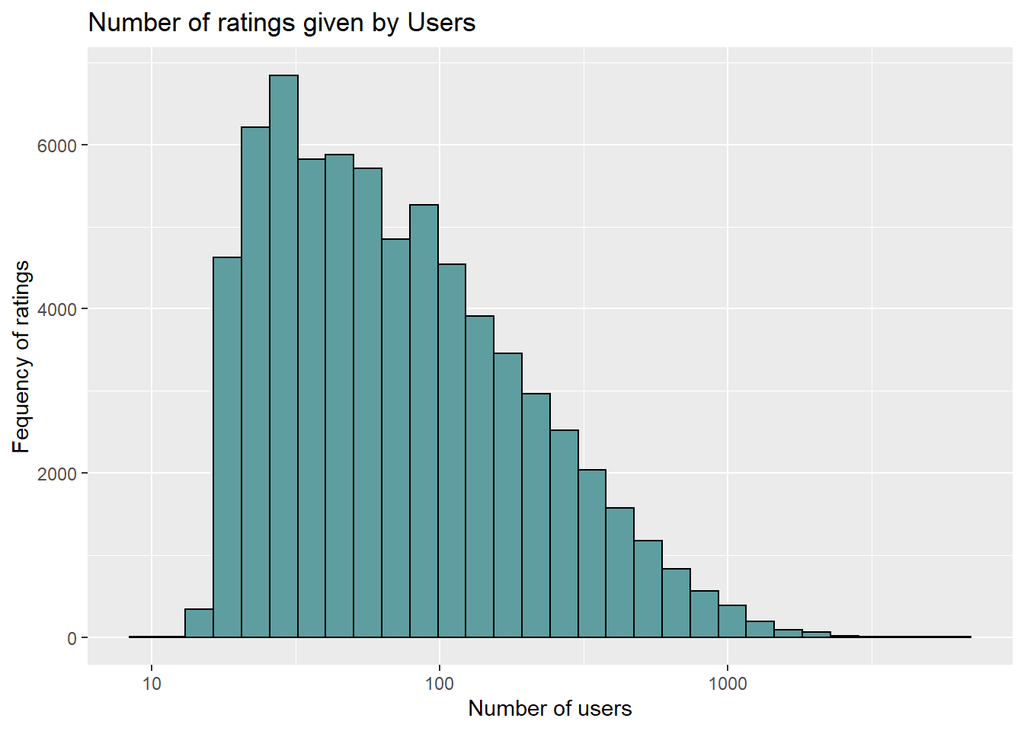

```r
edx %>%
  count(userId) %>%
  ggplot(aes(n)) +
  geom_histogram(bins = 30,  fill='cadetblue', color='black') +
  scale_x_log10() +
  xlab("Number of users") +
  ylab("Fequency of ratings") +
  ggtitle("Number of ratings given by Users")
```

The dataset has around 10400 unique movies.

```r
edx %>%
summarize(users = n_distinct(title))
```

| users |
| --- |
| 10407 |

The release years for movies in range 1915 to 2008. Most movies belong to recent years ranging from 1980 to 2000. Though, it would be nice to have more movies from old years to make model more robust.

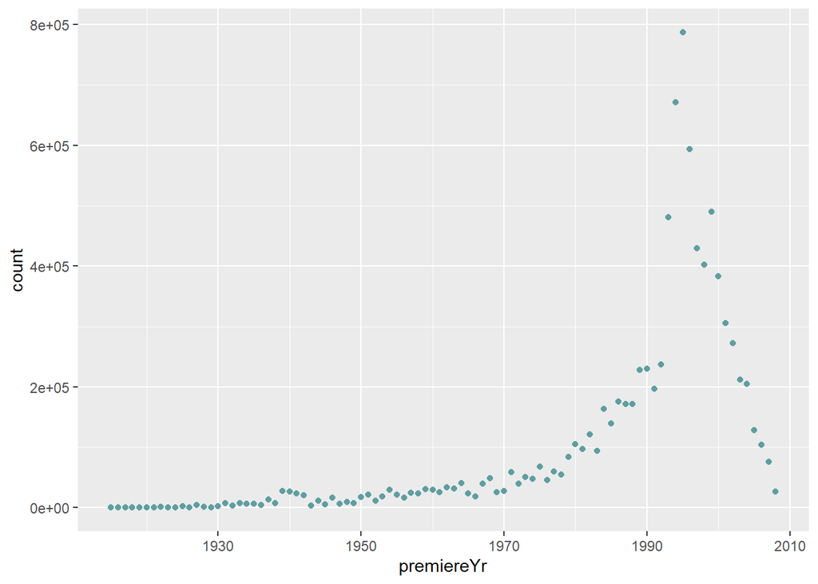

```r
edx %>%
  select(movieId, premiereYr) %>% # select columns we need
  group_by(premiereYr) %>% # group by year
  summarise(count = n())  %>% # count movies per year
  arrange(premiereYr)%>%
  ggplot(aes(x = premiereYr, y = count)) +
  geom_point(color="cadetblue")
```

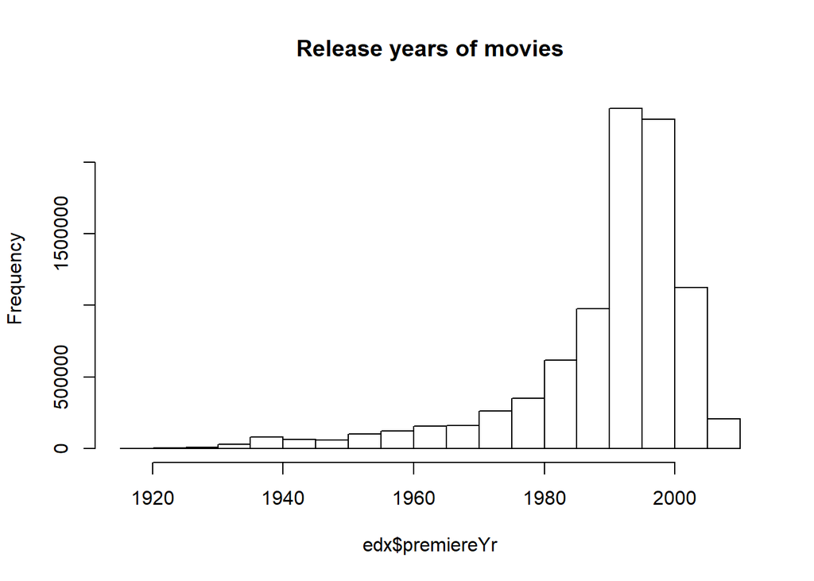

```r
hist(edx$premiereYr, main="Release years of movies")
```

The distribution of ratings for movies indicate that most movies get a decent number of ratings. Although some movies have less number fof ratings.This indicates that movie information can also be used as penalty term (if required).

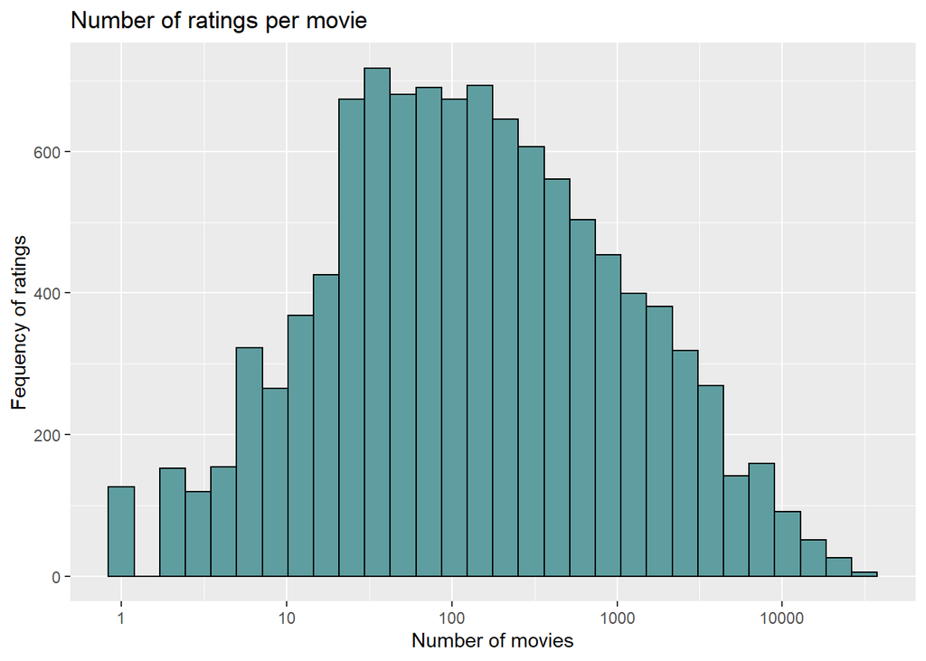

```r
#Distribution of Movie Ratings
edx %>% group_by(movieId) %>% summarize(n = n()) %>%
  ggplot(aes(n)) + geom_histogram(bins=30, fill = 'cadetblue', color = 'black') +
  scale_x_log10() +
  xlab("Number of movies") +
  ylab("Fequency of ratings") +
  ggtitle("Number of ratings per movie")
```

We observe that ratings data is collected over a span of around 14 years. All movies have at-least one rating. We also observe that there is a tendency that users generally rate movies 3 or 4.

```r
years<-format(edx$timestamp, format="%Y")
as.numeric(max(years))-as.numeric(min(years))
```

```
## [1] 14
```

The movies can have half or full stars ratings. The distribution indicates that most movies get full star ratings.

```r
print("Frequencies of ratings")
```

```
## [1] "Frequencies of ratings"
```

```r
sort(table(edx$rating))
```

```
##
##     0.5     1.5     2.5       1     4.5       2     3.5       5       3
##   85374  106426  333010  345679  526736  711422  791624 1390114 2121240
##       4
## 2588430
```

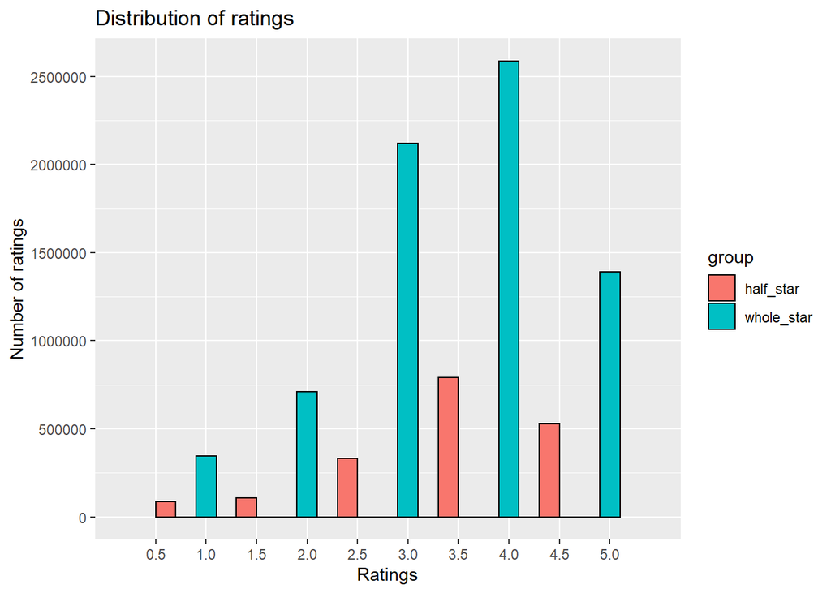

```r
# Generating groups of data for half star and full star ratings
group <-  ifelse((edx$rating == 1 |edx$rating == 2 | edx$rating == 3 |
                  edx$rating == 4 | edx$rating == 5) ,
                   "whole_star",
                   "half_star")

# Plotting the distribution of ratings
ratings_distribution <- data.frame(edx$rating, group)
ggplot(ratings_distribution, aes(x= edx.rating, fill = group)) +
  geom_histogram( binwidth = 0.2,color = 'black') +
  scale_x_discrete(limits = c(seq(0.5,5,0.5))) +
  scale_y_continuous(breaks = c(seq(0, 3000000, 500000)))+
  labs(x="Ratings", y="Number of ratings") +
  ggtitle("Distribution of ratings")
```

Top 10 movies are well-known and are rated by many users. But, the bottom 10 movies appear to be obscure and are only rated by one user. Therefore, the predictions of future ratings for such movies will be difficult.

This information is important for our model because a very low rating numbers can result in overfitting for our predictions. Therefore, the use of regularization by including this information as a penalty term in our model (if needed) can improve the RMSE of our model.

```r
movies_count<-(edx %>%
  group_by(title) %>%summarize(count=n()))


sprintf("Movies with a single rating = %d",sum(movies_count$count==1))
```

```
## [1] "Movies with a single rating = 125"
```

```r
top_movies <- edx %>%
  group_by(title) %>%
  summarize(count=n()) %>%
  top_n(10) %>%
  arrange(desc(count))
```

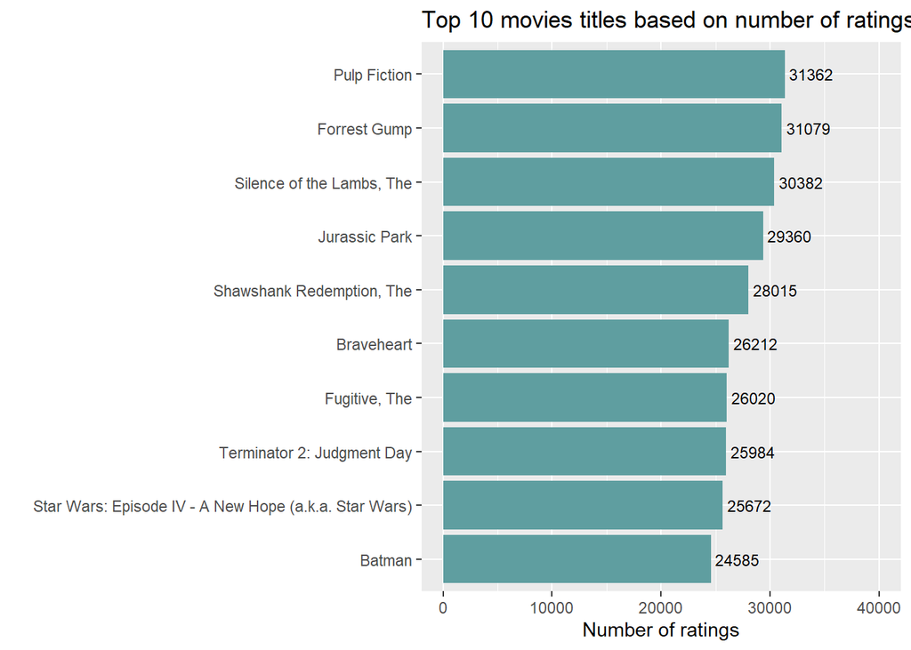

```r
top_movies %>%
  ggplot(aes(x=reorder(title, count), y=count)) +
  geom_bar(stat='identity', fill="cadetblue") + coord_flip(y=c(0, 40000)) +
  labs(x="", y="Number of ratings") +
  geom_text(aes(label= count), hjust=-0.1, size=3) +
  labs(title="Top 10 movies titles based on number of ratings" )
```

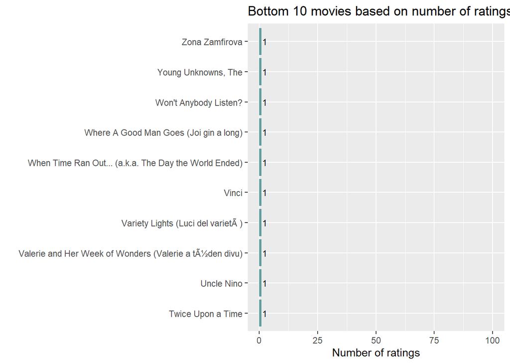

```r
bottom_movies <- edx %>%
  group_by(title) %>%
  summarize(count=n()) %>%
  arrange(desc(count))

bottom_movies %>% tail(10) %>%
  ggplot(aes(x=reorder(title, count), y=count)) +
  geom_bar(stat='identity', fill="cadetblue") + coord_flip(y=c(0, 100)) +
  labs(x="", y="Number of ratings") +
  geom_text(aes(label= count), hjust=-0.1, size=3) +
  labs(title="Bottom 10 movies based on number of ratings")
```

```r
generes <- c("Drama","Comedy","Thriller","Romance","Sci-Fi","Adventure","War","Action","Horror")
sapply(generes, function(x)
{
 sprintf("%s = %d",x,sum(grepl(x,edx$genres)))
}
)
```

```
##                 Drama                Comedy              Thriller
##     "Drama = 3910127"    "Comedy = 3540930"  "Thriller = 2325899"
##               Romance                Sci-Fi             Adventure
##   "Romance = 1712100"    "Sci-Fi = 1341183" "Adventure = 1908892"
##                   War                Action                Horror
##        "War = 511147"    "Action = 2560545"     "Horror = 691485"
```

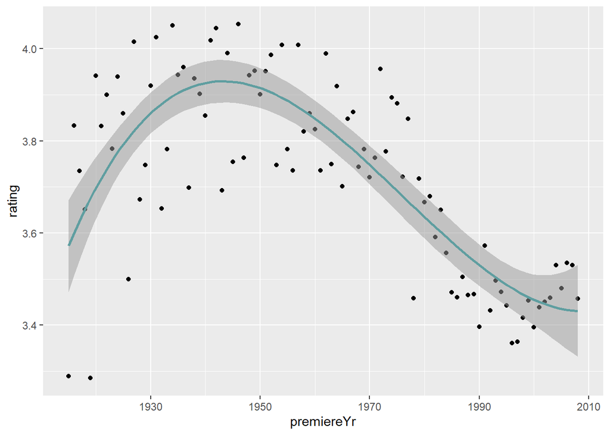

```r
edx %>% group_by(premiereYr) %>%
  summarize(rating = mean(rating)) %>%
  ggplot(aes(premiereYr, rating)) +
  geom_point() +
  geom_smooth(alpha=0.5, color='cadetblue',method = lm,formula = y ~ splines::bs(x, 3))
```

We will use RMSE to estimate the quality of our model. Using equation , we write the following function to compute the RMSE between actual ratings and predicted ratings::

```r
RMSE <- function(true_ratings, predicted_ratings){
  sqrt(mean((true_ratings - predicted_ratings)^2))
}
```

The lower RMSE is better.The evaluation criteria for this project is that RMSE of the proposed model should be less than 0.8649.

```r
#Initiate RMSE results to compare various models
rmse_results <- data_frame(method = "Target RSME", RMSE = 0.8649)
rmse_results
```

| method | RMSE |
| --- | --- |
| Target RSME | 0.8649 |

We start with the simplest model by predicting the same ratings for all movies regardless of users or freqeuncy of ratings. In other words, we compute the dataset’s mean raitng as follows:

$$\begin{equation}
Y_{u, i} = \mu + \epsilon_{u, i}
\end{equation}$$

Where $\epsilon_{u,i}$ is the independent error sample from the same distribution centered at 0 and $\mu$ the ``true" rating for all movies. This model is based on the assumption that differences in movie ratings can be explained by random variation alone. The expected value of the data is around 3.5 and we obtain a RMSE of 1.06.

```r
# Calculating mean of ratings
mu <- mean(edx$rating)
mu
```

```
## [1] 3.512465
```

We make predictions using $\mu$ and obtain our firt RMSE score of 1.06.

```r
# Making predictions using mean rating
naive_rmse <- RMSE(validation$rating, mu)
rmse_results <- bind_rows(rmse_results,
                          data_frame(method="Average Rating Model",
                                     RMSE = naive_rmse ))
rmse_results
```

| method | RMSE |
| --- | --- |
| Target RSME | 0.864900 |
| Average Rating Model | 1.061202 |

In order to improve the RMSE of our model, we have to include extra parameters in our model. We can use some of the insights obtained in previous section, such as user effect.

We recall from Section that different movies are rated differently. The popular movies are rated much higher than unpopular movies. We can modify our previous model by adding the term `$b_{i}$" to represent average ranking for movie i as follows:

$$\begin{equation}
Y_{u, i} = \mu +b_{i}+ \epsilon_{u, i}
\end{equation}$$

The least squares estimate $b_{i}$ is just the average of $Y_{u,i} - \mu$ for each movie $i$. So we can compute it as follows:

```r
mu <- mean(edx$rating)
movie_avgs <- edx %>%
  group_by(movieId) %>%
  summarize(b_i = mean(rating - mu))
```

The histogram is skewed to the left, which implies that most movies have negative effects. This is known as penalty term movie effect.

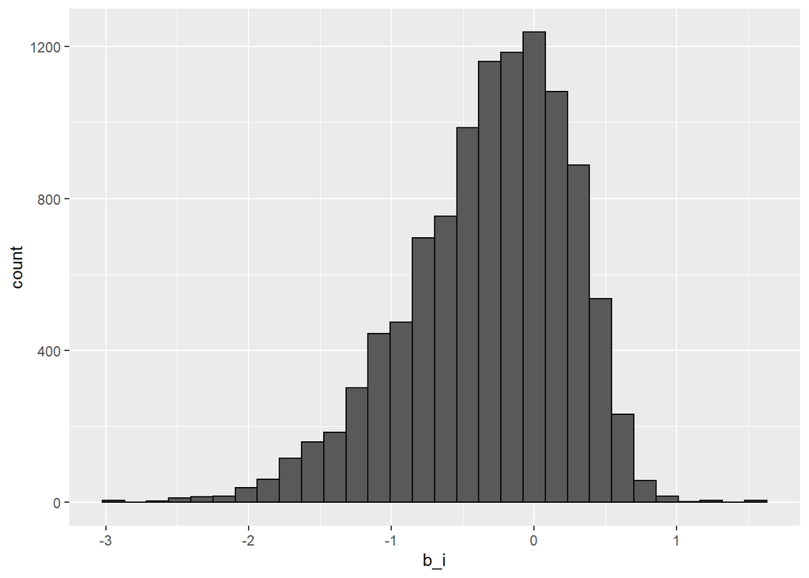

```r
movie_avgs%>%
ggplot(aes(b_i)) +
geom_histogram(bins = 30, color = "black")
```

```r
predicted_ratings <- mu +  validation %>%
  left_join(movie_avgs, by='movieId') %>%
  pull(b_i)
model_1_rmse <- RMSE(predicted_ratings, validation$rating)
rmse_results <- bind_rows(rmse_results,
                          data_frame(method="Movie effect model",
                                     RMSE = model_1_rmse ))
rmse_results
```

| method | RMSE |
| --- | --- |
| Target RSME | 0.8649000 |
| Average Rating Model | 1.0612018 |
| Movie effect model | 0.9439087 |

$$\begin{equation}
Y_{u, i} = \mu + b_{i} + b_{u} + \epsilon_{u, i}
\end{equation}$$

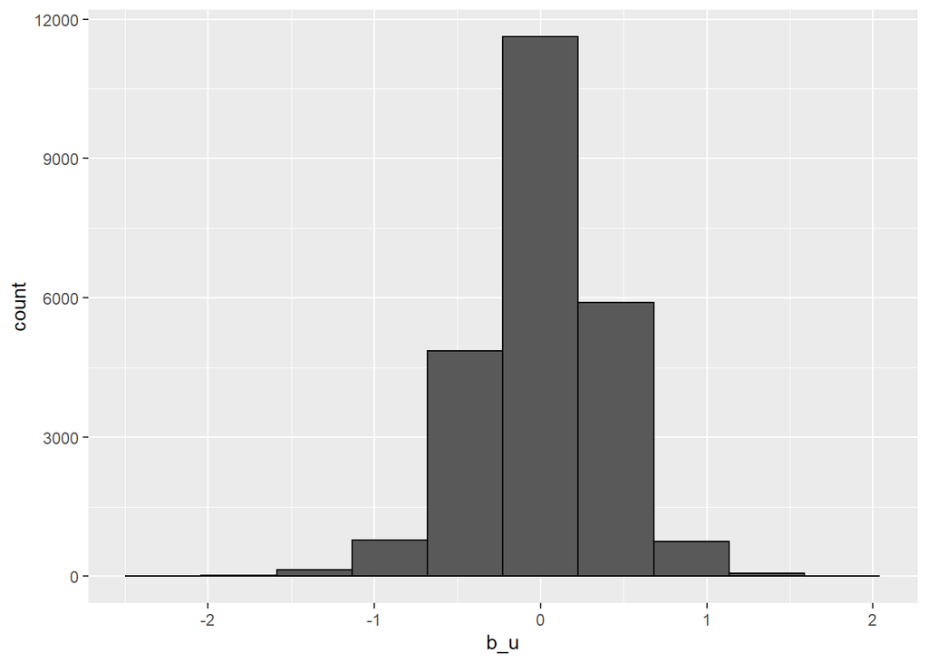

```r
edx %>%
  left_join(movie_avgs, by='movieId') %>%
  group_by(userId) %>%
  filter(n() >= 100) %>%
  summarize(b_u = mean(rating - mu - b_i)) %>%
  ggplot(aes(b_u)) +
  geom_histogram(bins = 10, color = "black")
```

If a cranky user (negative $b_{u}$) rates a great movie (positive $b_{i}$), the effects counter each other. And, we may be able to correctly predict that this user gave this great movie a 3 rather than a 5. We estimate $b_{u}$ as the average of
$$Y_{u, i} - \mu - b_{i}$$
as shown below.

```r
user_avgs <- edx %>%
left_join(movie_avgs, by='movieId') %>%
group_by(userId) %>%
summarize(b_u = mean(rating - mu - b_i))
```

By using new model for prediction, the RMSE improves to 0.865.

```r
predicted_ratings <- validation%>%
  left_join(movie_avgs, by='movieId') %>%
  left_join(user_avgs, by='userId') %>%
  mutate(pred = mu + b_i + b_u) %>%
  pull(pred)
model_2_rmse <- RMSE(predicted_ratings, validation$rating)
rmse_results <- bind_rows(rmse_results,
                          data_frame(method="Movie and user effect model",
                                     RMSE = model_2_rmse))
rmse_results
```

| method | RMSE |
| --- | --- |
| Target RSME | 0.8649000 |
| Average Rating Model | 1.0612018 |
| Movie effect model | 0.9439087 |
| Movie and user effect model | 0.8653488 |

There is still room for improvement as we stil made mistakes on our first model (using only movies). There are users who have rated very few movies (less than 30 movies). On the other hand, some movies are rated very few times (say 1 or 2). These are basically noisy estimates that result in overfitting of the model. Such large errors are likely increase the RMSE and affect our predictions.

To tackle this problem, we use the concept of regularization. The regularization permits to penalize large estimates that come from small sample sizes. First, we find the value of lambda (that is a tuning parameter) that will minimize the RMSE.

```r
library(tidyverse)
lambdas <- seq(0, 10, 0.25)
rmses <- sapply(lambdas, function(l){

  mu <- mean(edx$rating)

  b_i <- edx %>%
    group_by(movieId) %>%
    summarize(b_i = sum(rating - mu)/(n()+l))

  b_u <- edx %>%
    left_join(b_i, by="movieId") %>%
    group_by(userId) %>%
    summarize(b_u = sum(rating - b_i - mu)/(n()+l))

  predicted_ratings <-
    validation %>%
    left_join(b_i, by = "movieId") %>%
    left_join(b_u, by = "userId") %>%
    mutate(pred = mu + b_i + b_u) %>%
    pull(pred)

  return(RMSE(predicted_ratings, validation$rating))
})
```

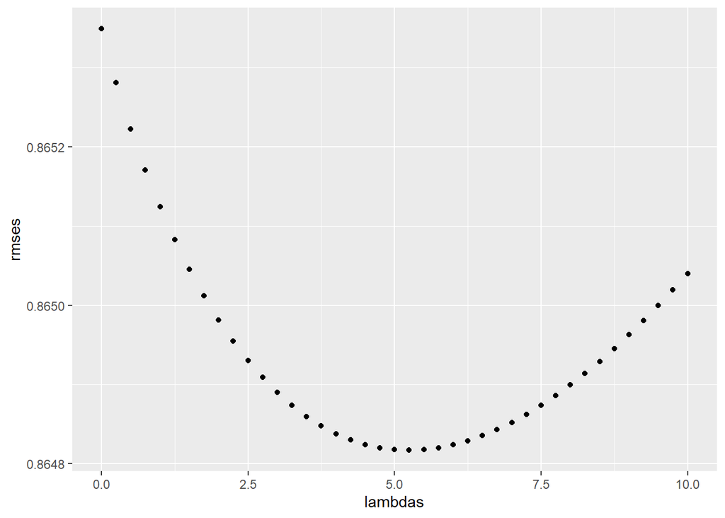

```r
qplot(lambdas, rmses)
```

```r
lambda <- lambdas[which.min(rmses)]
lambda
```

```
## [1] 5.25
```

```r
rmse_results <- bind_rows(rmse_results,
                          data_frame(method="Regularized movie and user effect model",
                                     RMSE = min(rmses)))
rmse_results
```

| method | RMSE |
| --- | --- |
| Target RSME | 0.8649000 |
| Average Rating Model | 1.0612018 |
| Movie effect model | 0.9439087 |
| Movie and user effect model | 0.8653488 |
| Regularized movie and user effect model | 0.8648170 |

We can analyse the RMSEs for the various models trained in the previouse section. We started with a very basic approach of predicting the mean ratingregardless of the user. Then, we added movie and user effects to the simple model. Finally, we experimented regularization with movie and user effects. For regularization, we found the optimal value of turing parameter$λ$.The resultant RMSEs are as follows:

```r
rmse_results
```

| method | RMSE |
| --- | --- |
| Target RSME | 0.8649000 |
| Average Rating Model | 1.0612018 |
| Movie effect model | 0.9439087 |
| Movie and user effect model | 0.8653488 |
| Regularized movie and user effect model | 0.8648170 |

We can see that the RMSE of our final model is 0.864817. This is a significant improvement (decrease in RMSE of around 18.5%) compared to the first simple model.

```r
rmse_results
```

| method | RMSE |
| --- | --- |
| Target RSME | 0.8649000 |
| Average Rating Model | 1.0612018 |
| Movie effect model | 0.9439087 |
| Movie and user effect model | 0.8653488 |
| Regularized movie and user effect model | 0.8648170 |